# A/B Testing

Nazmul

2023-10-30

Bayesian A/B testing offers significant advantages over frequentist approaches. In frequentist tests, point estimates are used, leading to interpretation challenges. Statisticians must conduct power tests, communicate results to non-technical stakeholders, and often struggle with interpretability. In contrast, Bayesian A/B testing enhances interpretability by providing direct probabilities of one variant’s superiority over another. It replaces p-values with these probabilities, making it easier to understand the results. Bayesian tests offer posterior distributions for parameters, allowing for various summarization methods. They are also robust against data “peeking” and maintain validity if a test is halted prematurely.

# Case Study

### Scenario

A fast-food chain plans to add a new item to its menu. However, they are still undecided between three possible marketing campaigns for promoting the new product. In order to determine which promotion has the greatest effect on sales, the new item is introduced at locations in several randomly selected markets. A different promotion is used at each location, and the weekly sales of the new item are recorded for the first four weeks.

## Goal

Evaluate A/B testing results and decide which marketing strategy works the best.

## Columns

MarketID: unique identifier for market  
MarketSize: size of market area by sales  
LocationID: unique identifier for store location  
AgeOfStore: age of store in years  
Promotion: one of three promotions that were tested  
week: one of four weeks when the promotions were run  
SalesInThousands: sales amount for a specific LocationID, Promotion, and week

### required libries

```r
library(tidyverse)
library(bayesAB)
dt <- read.csv("WA_Marketing-Campaign.csv")
```

### EDA

```r
summary(dt)
```

```
##     MarketID       MarketSize          LocationID      AgeOfStore
##  Min.   : 1.000   Length:548         Min.   :  1.0   Min.   : 1.000
##  1st Qu.: 3.000   Class :character   1st Qu.:216.0   1st Qu.: 4.000
##  Median : 6.000   Mode  :character   Median :504.0   Median : 7.000
##  Mean   : 5.715                      Mean   :479.7   Mean   : 8.504
##  3rd Qu.: 8.000                      3rd Qu.:708.0   3rd Qu.:12.000
##  Max.   :10.000                      Max.   :920.0   Max.   :28.000
##    Promotion          week      SalesInThousands
##  Min.   :1.000   Min.   :1.00   Min.   :17.34
##  1st Qu.:1.000   1st Qu.:1.75   1st Qu.:42.55
##  Median :2.000   Median :2.50   Median :50.20
##  Mean   :2.029   Mean   :2.50   Mean   :53.47
##  3rd Qu.:3.000   3rd Qu.:3.25   3rd Qu.:60.48
##  Max.   :3.000   Max.   :4.00   Max.   :99.65
```

```r
glimpse(dt)
```

```
## Rows: 548
## Columns: 7
## $ MarketID         <int> 1, 1, 1, 1, 1, 1, 1, 1, 1, 1, 1, 1, 1, 1, 1, 1, 1, 1,…
## $ MarketSize       <chr> "Medium", "Medium", "Medium", "Medium", "Medium", "Me…
## $ LocationID       <int> 1, 1, 1, 1, 2, 2, 2, 2, 3, 3, 3, 3, 4, 4, 4, 4, 5, 5,…
## $ AgeOfStore       <int> 4, 4, 4, 4, 5, 5, 5, 5, 12, 12, 12, 12, 1, 1, 1, 1, 1…
## $ Promotion        <int> 3, 3, 3, 3, 2, 2, 2, 2, 1, 1, 1, 1, 2, 2, 2, 2, 2, 2,…
## $ week             <int> 1, 2, 3, 4, 1, 2, 3, 4, 1, 2, 3, 4, 1, 2, 3, 4, 1, 2,…
## $ SalesInThousands <dbl> 33.73, 35.67, 29.03, 39.25, 27.81, 34.67, 27.98, 27.7…
```

```r
dt$Promotion <- as.character(dt$Promotion)
```

```r
#grouping data by Promotion
png(filename="prom_vs_perct.png", res=500, width=3312, height=1600)
prom <- dt %>%
  group_by(Promotion) %>%
  summarize(Sales=sum(SalesInThousands))%>%
  mutate(Percentage=round(Sales/sum(Sales)*100))

prom %>%
  ggplot(aes(x= Promotion, y = Percentage, fill= Promotion)) +
  geom_bar(stat = "identity") +  scale_fill_hue(labels = c("Prom 1", "Prom 2", "Prom 3")) + geom_text(aes(label = Percentage)) +
theme_minimal() +
theme(axis.text.x = element_blank(),
axis.title.x = element_blank(),
panel.grid = element_blank())
```

```r
png(filename="marsize.png", res=500, width=3312, height=1600)

msize <- dt %>%
  group_by(Promotion, MarketSize) %>%
  summarize(count= n())
```

```r
msize %>% ggplot(aes(x= Promotion, y = count, fill= MarketSize)) +
  geom_bar(stat = "identity", position="dodge") +
  theme_minimal() +
theme(panel.grid = element_blank())
```

```r
#normality check
shapiro.test(dt$SalesInThousands[dt$Promotion=="1"])
```

```
##
##  Shapiro-Wilk normality test
##
## data:  dt$SalesInThousands[dt$Promotion == "1"]
## W = 0.9153, p-value = 1.977e-08
```

```r
shapiro.test(dt$SalesInThousands[dt$Promotion=="2"])
```

```
##
##  Shapiro-Wilk normality test
##
## data:  dt$SalesInThousands[dt$Promotion == "2"]
## W = 0.91451, p-value = 5.457e-09
```

```r
shapiro.test(dt$SalesInThousands[dt$Promotion=="3"])
```

```
##
##  Shapiro-Wilk normality test
##
## data:  dt$SalesInThousands[dt$Promotion == "3"]
## W = 0.92077, p-value = 1.499e-08
```

```r
# mean, standard deviation
mean(dt$SalesInThousands[dt$Promotion=="1"])
```

```
## [1] 58.09901
```

```r
mean(dt$SalesInThousands[dt$Promotion=="2"])
```

```
## [1] 47.32941
```

```r
mean(dt$SalesInThousands[dt$Promotion=="3"])
```

```
## [1] 55.36447
```

```r
sd(dt$SalesInThousands[dt$Promotion=="1"])
```

```
## [1] 16.55378
```

```r
sd(dt$SalesInThousands[dt$Promotion=="2"])
```

```
## [1] 15.10895
```

```r
sd(dt$SalesInThousands[dt$Promotion=="3"])
```

```
## [1] 16.76623
```

```r
prom_1 <- rnorm(172, 58.09901, 16.55378)
prom_2 <- rnorm(188, 47.32941, 15.10895)
prom_3 <- rnorm(188, 55.36447, 16.76623)
```

```r
pm12 <- bayesTest(prom_1, prom_2,
          priors = c('mu' = 5, 'lambda' = 2, 'alpha' = 3, 'beta' = 1), distribution = 'normal')
pm12
```

```
## --------------------------------------------
## Distribution used: normal
## --------------------------------------------
## Using data with the following properties:
##                 A         B
## Min.     14.44738  9.581652
## 1st Qu.  48.43372 37.798468
## Median   60.30888 45.694971
## Mean     59.29011 47.100155
## 3rd Qu.  69.68517 56.579986
## Max.    102.95513 82.718641
## --------------------------------------------
## Conjugate Prior Distribution: NormalInvGamma
## Conjugate Prior Parameters:
## $mu
## [1] 5
##
## $lambda
## [1] 2
##
## $alpha
## [1] 3
##
## $beta
## [1] 1
##
## --------------------------------------------
## Calculated posteriors for the following parameters:
## Mu, Sig_Sq
## --------------------------------------------
## Monte Carlo samples generated per posterior:
## [1] 1e+05
```

```r
summary(pm12)
```

```
## Quantiles of posteriors for A and B:
##
## $Mu
## $Mu$A
##       0%      25%      50%      75%     100%
## 52.54830 57.76266 58.65809 59.54913 64.32598
##
## $Mu$B
##       0%      25%      50%      75%     100%
## 41.94391 45.94364 46.65890 47.37320 51.27599
##
##
## $Sig_Sq
## $Sig_Sq$A
##       0%      25%      50%      75%     100%
## 196.5705 283.0131 303.5943 326.4840 521.1828
##
## $Sig_Sq$B
##       0%      25%      50%      75%     100%
## 142.2889 198.5689 212.4887 227.7755 347.7891
##
##
## --------------------------------------------
##
## P(A > B) by (0, 0)%:
##
## $Mu
## [1] 1
##
## $Sig_Sq
## [1] 0.99204
##
## --------------------------------------------
##
## Credible Interval on (A - B) / B for interval length(s) (0.9, 0.9) :
##
## $Mu
##        5%       95%
## 0.1923901 0.3251759
##
## $Sig_Sq
##        5%       95%
## 0.1201566 0.8204674
##
## --------------------------------------------
##
## Posterior Expected Loss for choosing A over B:
##
## $Mu
## [1] 0
##
## $Sig_Sq
## [1] 0.0004087615
```

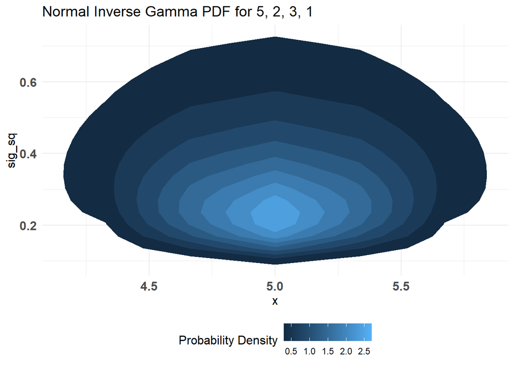

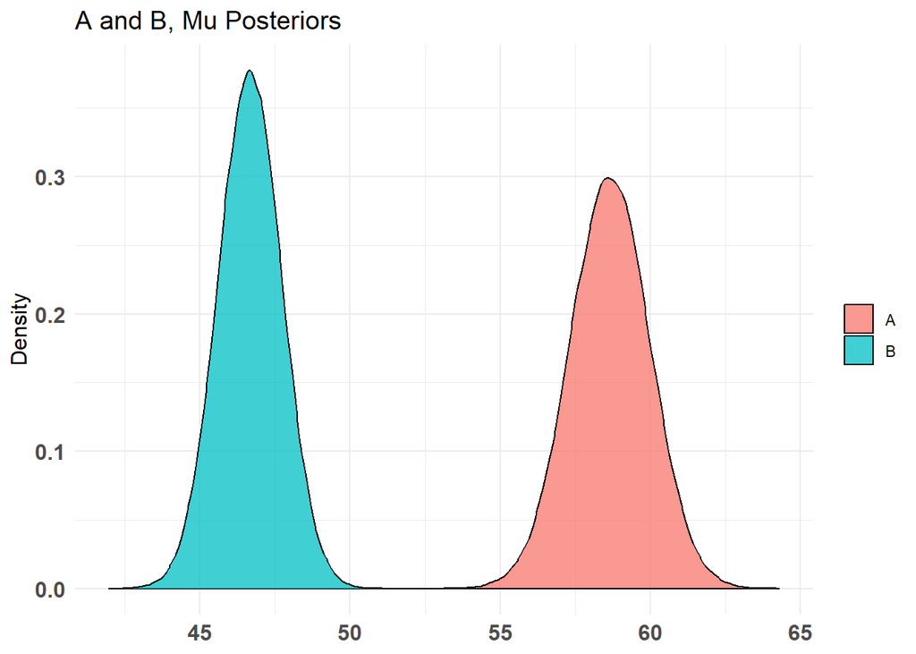

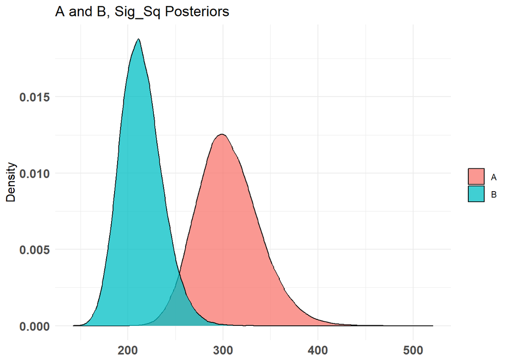

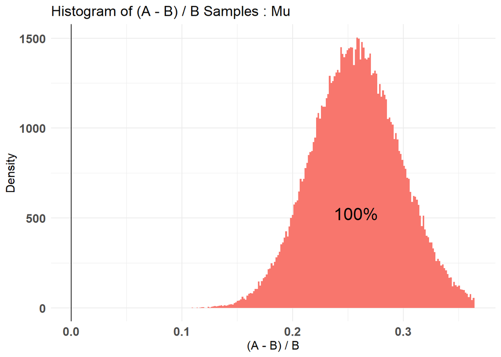

```r
plot(pm12)
```

```r
pm13 <- bayesTest(prom_1, prom_3,
          priors = c('mu' = 5, 'lambda' = 1, 'alpha' = 3, 'beta' = 1),
                 distribution = 'normal')
pm13
```

```
## --------------------------------------------
## Distribution used: normal
## --------------------------------------------
## Using data with the following properties:
##                 A         B
## Min.     14.44738  4.143368
## 1st Qu.  48.43372 43.473495
## Median   60.30888 55.870542
## Mean     59.29011 55.306666
## 3rd Qu.  69.68517 67.273834
## Max.    102.95513 97.525066
## --------------------------------------------
## Conjugate Prior Distribution: NormalInvGamma
## Conjugate Prior Parameters:
## $mu
## [1] 5
##
## $lambda
## [1] 1
##
## $alpha
## [1] 3
##
## $beta
## [1] 1
##
## --------------------------------------------
## Calculated posteriors for the following parameters:
## Mu, Sig_Sq
## --------------------------------------------
## Monte Carlo samples generated per posterior:
## [1] 1e+05
```

```r
summary(pm13)
```

```
## Quantiles of posteriors for A and B:
##
## $Mu
## $Mu$A
##       0%      25%      50%      75%     100%
## 53.00184 58.10896 58.97959 59.84895 65.10418
##
## $Mu$B
##       0%      25%      50%      75%     100%
## 49.26679 54.19372 55.03652 55.88950 60.58631
##
##
## $Sig_Sq
## $Sig_Sq$A
##       0%      25%      50%      75%     100%
## 182.0258 267.7170 287.4217 309.0822 462.5544
##
## $Sig_Sq$B
##       0%      25%      50%      75%     100%
## 205.6688 280.5871 300.2052 321.8776 498.2252
##
##
## --------------------------------------------
##
## P(A > B) by (0, 0)%:
##
## $Mu
## [1] 0.98475
##
## $Sig_Sq
## [1] 0.38371
##
## --------------------------------------------
##
## Credible Interval on (A - B) / B for interval length(s) (0.9, 0.9) :
##
## $Mu
##         5%        95%
## 0.01691469 0.12937835
##
## $Sig_Sq
##         5%        95%
## -0.2484324  0.2183568
##
## --------------------------------------------
##
## Posterior Expected Loss for choosing A over B:
##
## $Mu
## [1] 0.000172878
##
## $Sig_Sq
## [1] 0.09234074
```

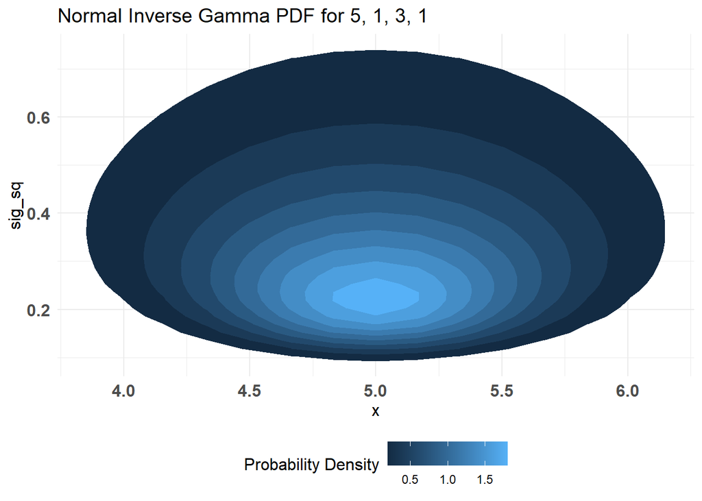

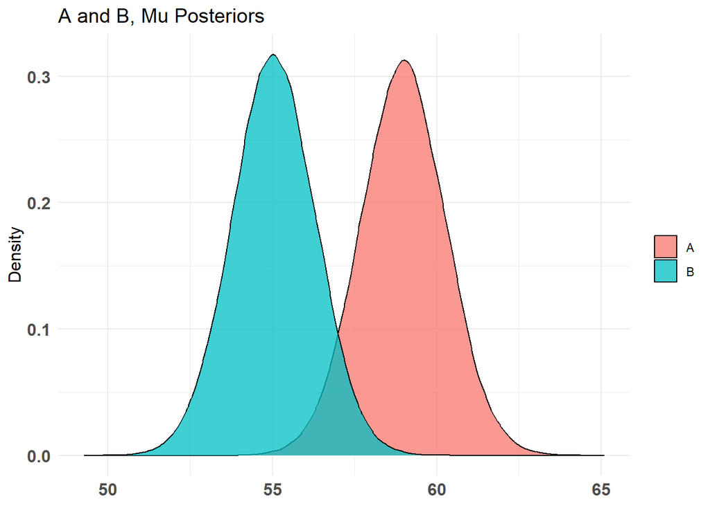

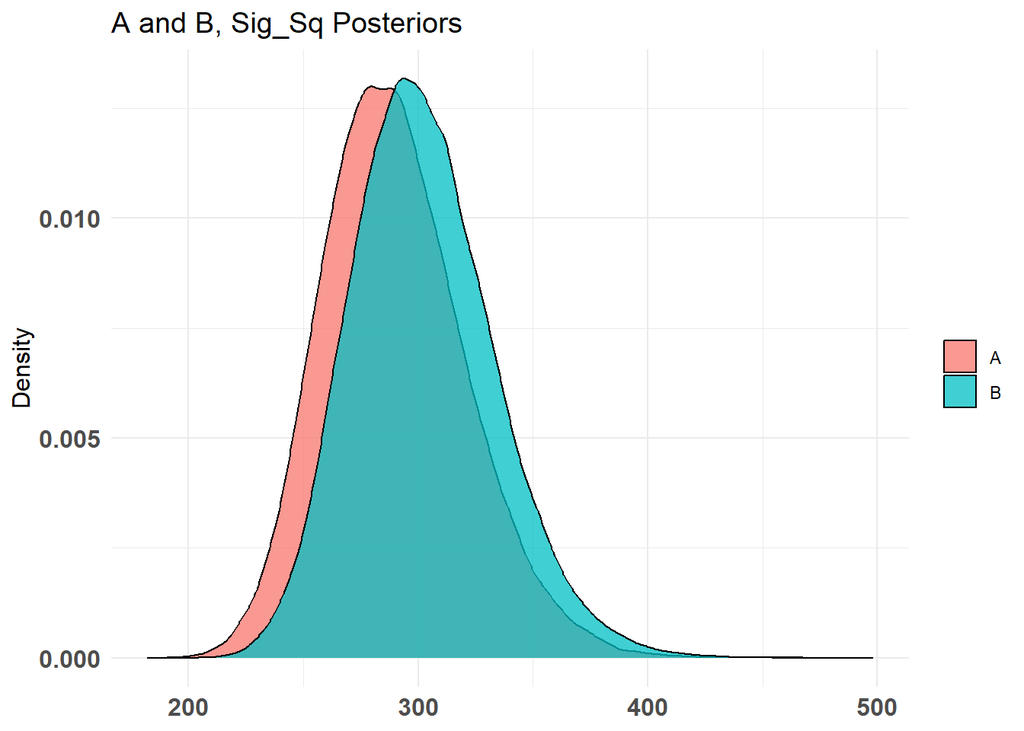

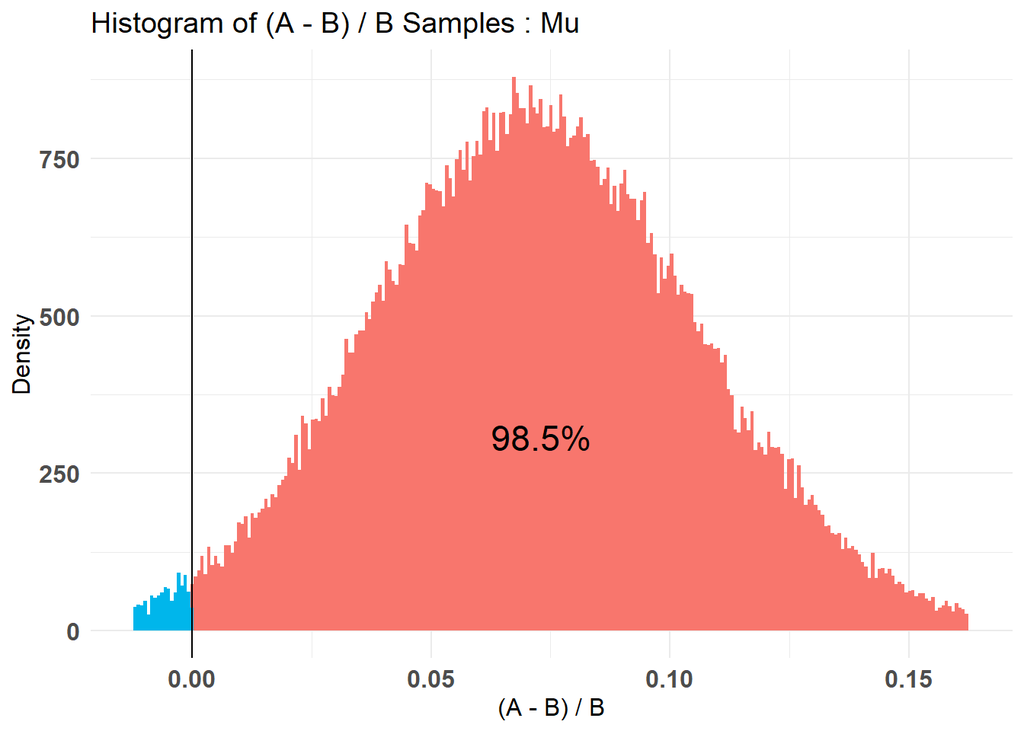

```r
plot(pm13)
```

Promotion 1 outperform promotion 2, and 3.